# Historical trends demonstrate a pattern of increasingly frequent and severe spillover events of high-consequence zoonotic viruses

Amanda J. Meadows, PhD*, Nicole Stephenson, PhD, Nita K. Madhav, MSPH, and Ben Oppenheim, PhD

2023-08-11

# Introduction

- This script shows all analyses performed for “Historical trends demonstrate a pattern of increasingly frequent and severe spillover events of high-consequence zoonotic viruses”
- The annual number of spillover events and deaths caused by selected pathogens and occurring between 1960 and 2019 were analyzed.

# Selected Pathogens

The pathogens included in this analysis after exclusion criteria (see Box 1 in paper text and Supplementary Table 1) were: SARS Coronavirus, Ebolaviruses, Marburg virus, Nipah virus, and Machupo virus.

## Data summary

The number of outbreaks and deaths by each selected pathogen 1960 through 2019:

| Pathogen | Spillover events | Deaths |
| --- | --- | --- |
| Zaire ebolavirus | 21 | 14798 |
| SARS-CoV | 2 | 922 |
| Marburg virus | 9 | 477 |
| Sudan ebolavirus | 7 | 426 |
| Nipah virus | 25 | 375 |
| Machupo virus | 8 | 154 |
| Bundibugyo ebolavirus | 2 | 70 |
| Tai Forest ebolavirus | 1 | 0 |

# Spillover Map

A map showing proportion of total included spillover events caused by Ebolaviruses, Marburg virus, SARS Coronavirus, Nipah virus, and Machupo virus, by country. Countries are shaded by proportion of spillover events; unshaded countries have no documented spillover of the included pathogens.

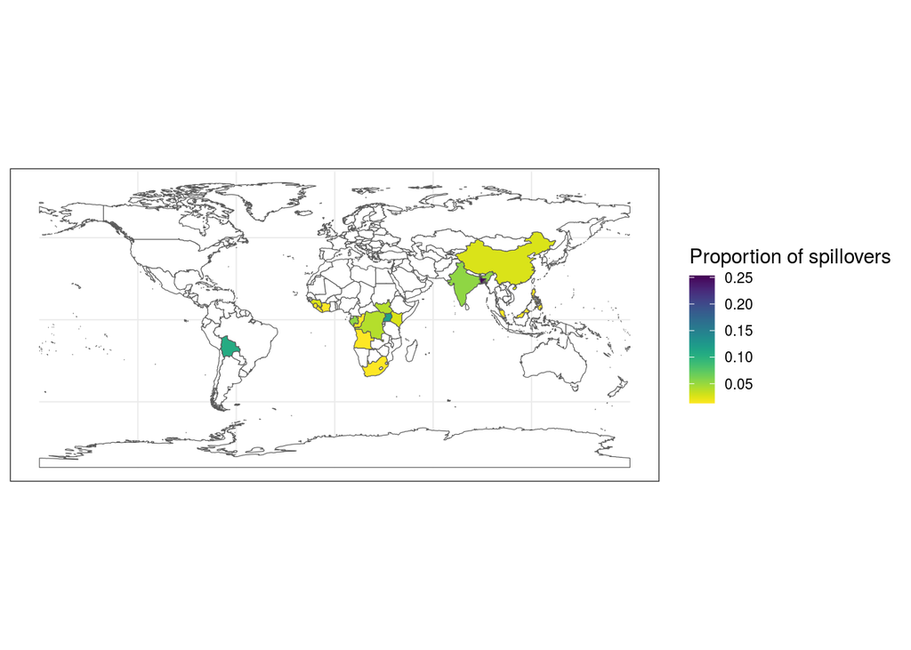

# Annual trend

- Analyzing trend in annual spillover events and deaths caused by Ebolaviruses, Marburg virus, SARS Coronavirus, Nipah virus, and Machupo virus from 1960 through 2019 (training data excludes ongoing events).
- Comparing a Poisson and negative binoimal fit.

## Spillover events

### Distribution

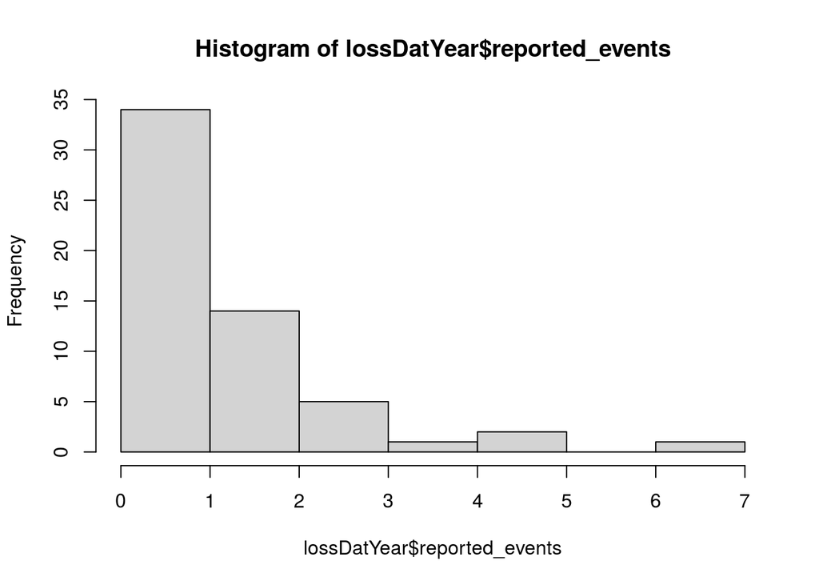

### Poisson fit

```
##
## Call:
## glm(formula = reported_events ~ Event_start_year, family = "poisson",
##     data = lossDatYear)
##
## Deviance Residuals:
##     Min       1Q   Median       3Q      Max
## -2.0067  -1.0258  -0.3878   0.6190   2.6455
##
## Coefficients:
##                    Estimate Std. Error z value Pr(>|z|)
## (Intercept)      -95.441825  16.633172  -5.738 9.58e-09 ***
## Event_start_year   0.047927   0.008306   5.770 7.91e-09 ***
## ---
## Signif. codes:  0 '***' 0.001 '**' 0.01 '*' 0.05 '.' 0.1 ' ' 1
##
## (Dispersion parameter for poisson family taken to be 1)
##
##     Null deviance: 101.131  on 56  degrees of freedom
## Residual deviance:  61.768  on 55  degrees of freedom
## AIC: 153.35
##
## Number of Fisher Scoring iterations: 5
```

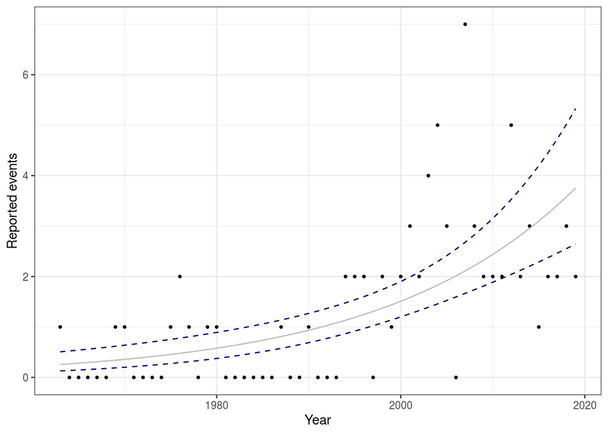

#### AIC

```
## [1] 153.3537
```

### Negative binomial

```
##
## Call:
## glm.nb(formula = reported_events ~ Event_start_year, data = lossDatYear,
##     init.theta = 20.81802079, link = log)
##
## Deviance Residuals:
##     Min       1Q   Median       3Q      Max
## -1.9652  -1.0129  -0.3769   0.6005   2.4443
##
## Coefficients:
##                    Estimate Std. Error z value Pr(>|z|)
## (Intercept)      -96.726055  17.246075  -5.609 2.04e-08 ***
## Event_start_year   0.048570   0.008614   5.639 1.71e-08 ***
## ---
## Signif. codes:  0 '***' 0.001 '**' 0.01 '*' 0.05 '.' 0.1 ' ' 1
##
## (Dispersion parameter for Negative Binomial(20.818) family taken to be 1)
##
##     Null deviance: 95.502  on 56  degrees of freedom
## Residual deviance: 58.194  on 55  degrees of freedom
## AIC: 155.17
##
## Number of Fisher Scoring iterations: 1
##
##
##               Theta:  20.8
##           Std. Err.:  52.6
##
##  2 x log-likelihood:  -149.174
```

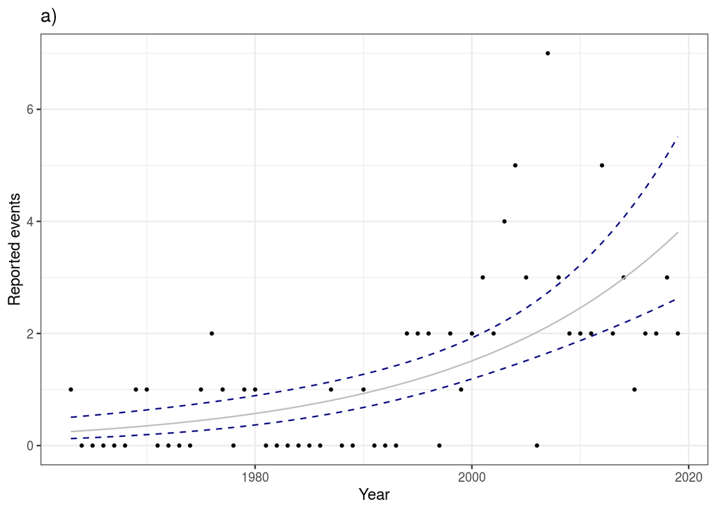

#### AIC

```
## [1] 155.1745
```

## Deaths

### Distribution

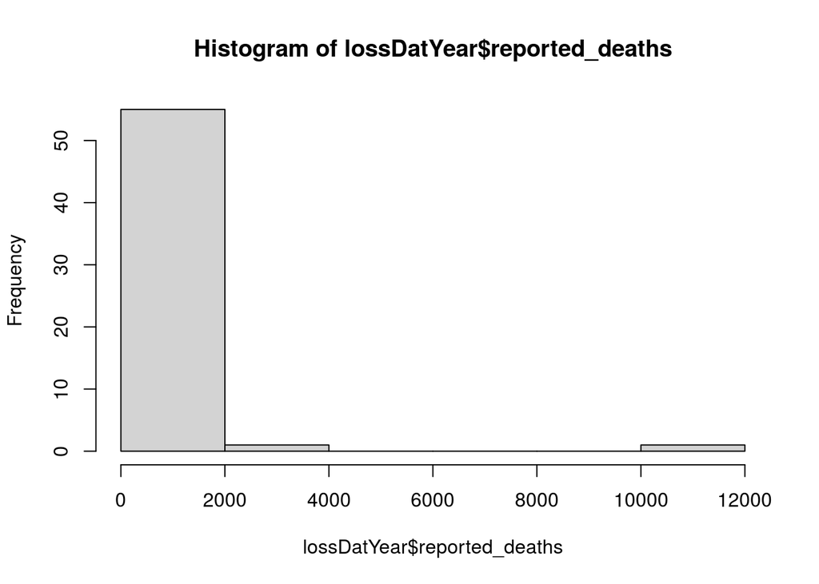

### Poisson fit

```
##
## Call:
## glm(formula = reported_deaths ~ Event_start_year, family = "poisson",
##     data = lossDatYear)
##
## Deviance Residuals:
##     Min       1Q   Median       3Q      Max
## -59.229  -14.374   -7.858   -3.265  189.379
##
## Coefficients:
##                    Estimate Std. Error z value Pr(>|z|)
## (Intercept)      -2.142e+02  1.750e+00  -122.4   <2e-16 ***
## Event_start_year  1.098e-01  8.705e-04   126.1   <2e-16 ***
## ---
## Signif. codes:  0 '***' 0.001 '**' 0.01 '*' 0.05 '.' 0.1 ' ' 1
##
## (Dispersion parameter for poisson family taken to be 1)
##
##     Null deviance: 91432  on 56  degrees of freedom
## Residual deviance: 62246  on 55  degrees of freedom
## AIC: 62430
##
## Number of Fisher Scoring iterations: 7
```

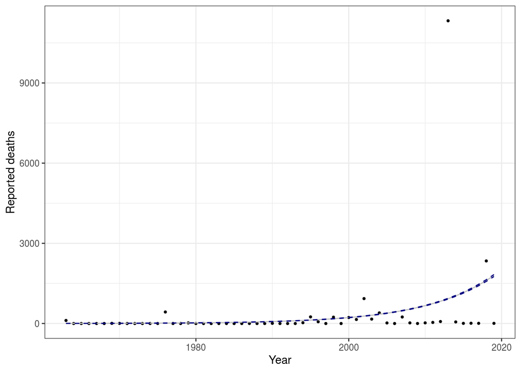

#### AIC

```
## [1] 62430.1
```

### Negative binomial

```
##
## Call:
## glm.nb(formula = reported_deaths ~ Event_start_year, data = lossDatYear,
##     init.theta = 0.129477238, link = log)
##
## Deviance Residuals:
##     Min       1Q   Median       3Q      Max
## -1.4371  -1.2077  -0.9480  -0.3172   1.8294
##
## Coefficients:
##                    Estimate Std. Error z value Pr(>|z|)
## (Intercept)      -162.10953   44.64035  -3.631 0.000282 ***
## Event_start_year    0.08377    0.02242   3.736 0.000187 ***
## ---
## Signif. codes:  0 '***' 0.001 '**' 0.01 '*' 0.05 '.' 0.1 ' ' 1
##
## (Dispersion parameter for Negative Binomial(0.1295) family taken to be 1)
##
##     Null deviance: 72.546  on 56  degrees of freedom
## Residual deviance: 57.265  on 55  degrees of freedom
## AIC: 457.1
##
## Number of Fisher Scoring iterations: 1
##
##
##               Theta:  0.1295
##           Std. Err.:  0.0253
##
##  2 x log-likelihood:  -451.0970
```

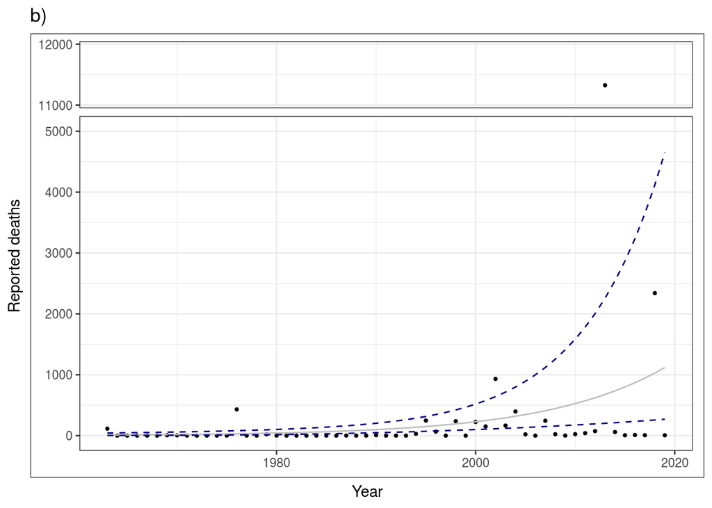

#### AIC

```
## [1] 457.0967
```

### Follow-up analysis: exclude West Africa Ebola event

- The West Africa Ebola event caused nearly 5 times more reported deaths than the next highest severity event in the dataset, which may be driving the significant temporal trend.
- Re-running the analysis excluding this event to ensure the significant temporal trend remains.

```
##
## Call:
## glm.nb(formula = reported_deaths ~ Event_start_year, data = lossDatYear_exclude,
##     init.theta = 0.1443350592, link = log)
##
## Deviance Residuals:
##     Min       1Q   Median       3Q      Max
## -1.4174  -1.2504  -0.8830  -0.3398   1.7947
##
## Coefficients:
##                    Estimate Std. Error z value Pr(>|z|)
## (Intercept)      -105.83831   42.27957  -2.503  0.01230 *
## Event_start_year    0.05527    0.02123   2.603  0.00925 **
## ---
## Signif. codes:  0 '***' 0.001 '**' 0.01 '*' 0.05 '.' 0.1 ' ' 1
##
## (Dispersion parameter for Negative Binomial(0.1443) family taken to be 1)
##
##     Null deviance: 64.446  on 56  degrees of freedom
## Residual deviance: 57.108  on 55  degrees of freedom
## AIC: 438.07
##
## Number of Fisher Scoring iterations: 1
##
##
##               Theta:  0.1443
##           Std. Err.:  0.0285
##
##  2 x log-likelihood:  -432.0690
```

## Conclusions

- Negative binomial model seems like the better choice for deaths due to overdispersion; not much difference between the models for events.
- Confidence intervals look better with negative binomial model.

# Future predictions

The total number of spillover events and deaths predicted to occur in 2020 and 2050 (±95% CI) according to the historical trend model.

| Year | Predicted spillover events | Predicted deaths |
| --- | --- | --- |
| 2020 | 4 [3 - 6] | 1,216 [281 - 5,252] |
| 2050 | 17 [7 - 40] | 15,007 [1019 - 220,960] |

# Contact

- Amanda Meadows: ameadows@ginkgobioworks.com